# GR5058 Data Mining Final Project

## Predicting

#### Model 1 - Linear Regression

```r
d <- select(data, -"date", -"quarter") # Disregard the time.

lm1 <- lm(dgx_adj_close ~ ., data = d)
#summary(lm1)
lm1_rmse <- sigma(lm1); lm1_rmse # RMSE 2.963882.
```

```
## [1] 2.963882
```

Tried using just variables that appear ‘statistically significant’ in the traditional sense of coefficient interpretation. As discussed in class, *significant* variables for prediction have a different meaning than significant variables for interpretation as in social science.

```r
lm2 <- lm(dgx_adj_close ~ gdp + us_mxp + lh_adj_close + dgx_volume + dgx_hv60, data = d)
#summary(lm2)
lm2_rmse <- sigma(lm2); lm2_rmse # RMSE 3.232503.
```

```
## [1] 3.232503
```

#### Model 2 - Random Forests

```r
#library(randomForest)
#library(caret)

set.seed(12202019) # Today's date.
d <- d[,c(1:7, 9:15, 8)] # Reordering the columns will make them easier to work with.
in_train <- createDataPartition(d$dgx_adj_close, p = 0.8, list = FALSE)
training <- d[ in_train, ]
testing <- d[-in_train, ]
```

Let’s figure out the best tuning parameters:

```r
#X <- training %>% select(-dgx_adj_close) %>% drop_na()
X <- as.matrix(drop_na(training[, 1:14]))
Y <- as.matrix(training[-c(17,33,82), 15])

#class(X)
#class(Y)
```

```r
tune_mtry <- tuneRF(X, Y, stepFactor = 1.5, improve = 1e-5, ntree = 1000)
```

```
## mtry = 4  OOB error = 11.61927
## Searching left ...
## mtry = 3     OOB error = 12.3655
## -0.06422284 1e-05
## Searching right ...
## mtry = 6     OOB error = 10.37755
## 0.1068672 1e-05
## mtry = 9     OOB error = 10.03326
## 0.03317664 1e-05
## mtry = 13    OOB error = 9.82817
## 0.02044122 1e-05
## mtry = 14    OOB error = 9.406711
## 0.04288277 1e-05
```

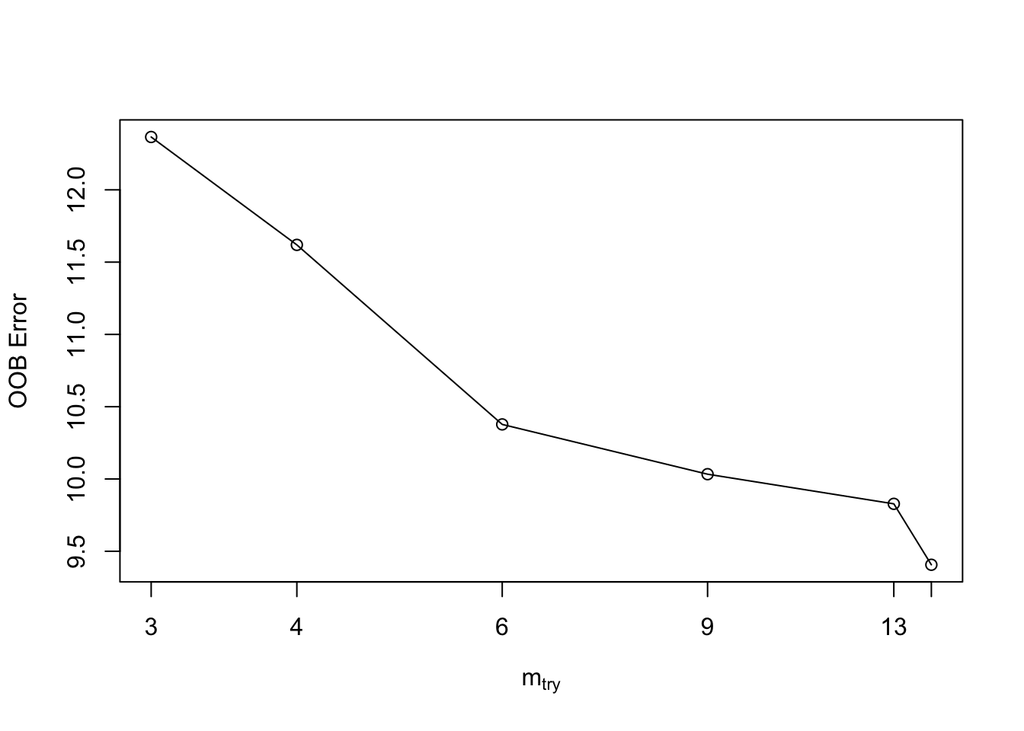

```r
print(tune_mtry) # Optimal # of mtry = 14.
```

```
##    mtry  OOBError
## 3     3 12.365496
## 4     4 11.619273
## 6     6 10.377554
## 9     9 10.033262
## 13   13  9.828170
## 14   14  9.406711
```

```r
rf_grid <- data.frame(.mtry = 14)
ctrl <- trainControl(method = "cv", number = 10)
out <- train(dgx_adj_close ~ ., data = training, method = "rf",
             trControl = ctrl, tuneGrid = rf_grid,
             ntrees = 1000, importance = TRUE, na.action = na.omit)
varImp(out)
```

```
## rf variable importance
##
##                      Overall
## lh_adj_close         100.000
## gdp                   58.101
## us_mxp                41.711
## dgx_hv60              25.219
## uk_us                 25.168
## dgx_hv20              23.283
## us_uk                 21.765
## us_bzr                21.688
## dgx_hv30              16.610
## bzr_us                15.493
## mxp_us                 8.343
## dgx_volume             7.677
## dgx_daily_tot_return   3.919
## lh_volume              0.000
```

The most predictive (important) variable here appears to be the adjusted close price of the competitor’s stock, then NYFED nowcasted GDP, and the US dollar to Mexican Pesos exchange rate to round out the top 3.

```r
y_hat <- predict(out, newdata = testing)
rf_rmse <- defaultSummary(data.frame(obs = testing$dgx_adj_close,
                          pred = y_hat)); rf_rmse # RMSE 2.2273334.
```

```
##      RMSE  Rsquared       MAE
## 2.2273334 0.9477089 1.5486140
```